```python
import keras
import numpy as np
import matplotlib.pyplot as plt
import matplotlib.cm as cm
import matplotlib.image as mpimg
import tensorflow as tf
import seaborn
config = tf.ConfigProto(
        device_count = {'GPU': 0}
    )
sess = tf.Session(config=config)
%matplotlib inline
```

# Helper Functions

```python
#np.cov not working as expected?
def cov(matrix):
    f = np.ones(matrix.shape[1])
    a = np.ones(matrix.shape[1])

    m = matrix.copy()
    w = f * a
    v1 = np.sum(w)
    v2 = np.sum(a)
    m -= np.sum(m * w, axis=1, keepdims=True) / v1
    _cov = np.dot(m * w, m.T) * v1 / (v1**2)
    return _cov

def prepare_covariance_matrix(matrix):
    covariance = cov(matrix)
    np.fill_diagonal(covariance, 0)
    return covariance

def create_adjacence_matrix_from_covariance(matrix,k=4,symmetric = True):
    adjacence_matrix,weighted_adjacence_matrix = knn_over_matrix(matrix)
    if symmetric:
        return force_symmetry(adjacence_matrix), force_symmetry(weighted_adjacence_matrix)
    else:
        return adjacence_matrix, weighted_adjacence_matrix


def knn_over_matrix(matrix,k=4):
    temp = np.argsort(-matrix,axis=1)[:,k-1] # Get K biggest index
    thresholds = matrix[np.arange(matrix.shape[0]),temp].reshape(-1,1) # Transform matrix into a column matrix of maximums
    adjacence_matrix = (matrix >= thresholds)*1.0 # Create adjacence_matrix
    weighted_adjacence_matrix = adjacence_matrix * matrix # Create weigthed adjacence_matrix
    return adjacence_matrix, weighted_adjacence_matrix

def force_symmetry(matrix):
    return np.minimum(matrix+matrix.T,1)
```

# Preprocessing

Generer matrice de covariance et un résultat de convolution «fake» pour tester les algorithmes

## CIFAR

Charger cifar et le mettre en gris.

```
x_train shape: (50000, 32, 32)
50000 train samples
10000 test samples
```

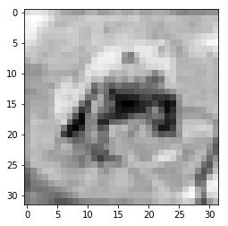

```python
(x_train, y_train), (x_test, y_test) = keras.datasets.cifar10.load_data()

x_train = x_train.astype('float32')
x_test = x_test.astype('float32')
x_train /= 255
x_test /= 255

def rgb2gray(rgb):
    return np.dot(rgb[...,:3], [0.299, 0.587, 0.114])

x_train_color = x_train.copy()

x_train = rgb2gray(x_train)
x_test = rgb2gray(x_test)

print('x_train shape:', x_train.shape)
print(x_train.shape[0], 'train samples')
print(x_test.shape[0], 'test samples')

plt.imshow(x_train[0], cmap = plt.get_cmap('Greys'))

x_train = x_train.reshape(-1,1024)
x_test = x_test.reshape(-1,1024)
```

## Covariance et fake convolution

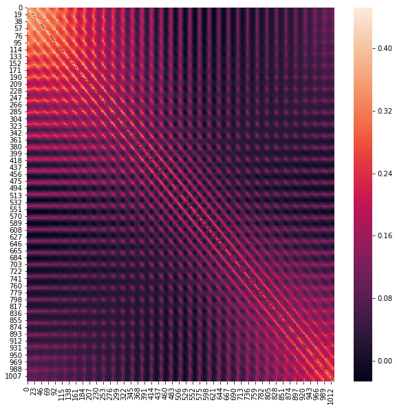

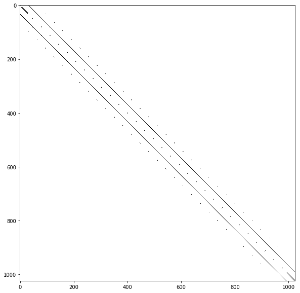

```python
def preprocessing(x_train):
    x_train_flattened = x_train.reshape(1024,-1)
    covariance = prepare_covariance_matrix(x_train)
    adjacence_matrix, weighted_adjacence_matrix = create_adjacence_matrix_from_covariance(covariance,4)
    convolution = np.concatenate([np.arange(3072).reshape(1,1024,3)+1, (np.arange(3072)+1)[::-1].reshape(1,1024,3)])
    return covariance,convolution, adjacence_matrix, weighted_adjacence_matrix
covariance,convolution, adjacence_matrix, weighted_adjacence_matrix = preprocessing(x_train.T)
plt.figure(figsize=(10,10))
seaborn.heatmap(covariance)
plt.figure(figsize=(10,10))
plt.imshow(adjacence_matrix,cmap="Greys")
```

# Pooling pour les réseau convolutionneles profonds sur graphe

Nous avons 4 pas pour faire le pooling:

Sur les 4 pas, nous avons des choses que vont être faites en numpy et d'autres en tensorflow pour qui keras puisse utiliser (après l'ideal serait de faire en keras avec K.backend)

## 1 - Choisir les noeuds du graphe à garder

- On va apeller ces noeuds «vivants»
  - Les noeuds que nous allons jeter seront les noeuds «morts»
- Pour le moment les noeuds seront choisis de manière aleatoire

### Seulement numpy, preprocessing

```python
def choose_nodes(adjacence_matrix,keep_pct = 0.25):
    np.random.seed(0)
    possible_indexes = np.arange(adjacence_matrix.shape[0])
    permutated_indexes = np.random.permutation(possible_indexes)
    alive_indexes = permutated_indexes[:int(possible_indexes.shape[0]*keep_pct)]
    dead_indexes = permutated_indexes[int(possible_indexes.shape[0]*keep_pct):]
    alive_indexes.sort()
    dead_indexes.sort()
    return alive_indexes,dead_indexes
alive_indexes,dead_indexes = choose_nodes(adjacence_matrix)
```

## 2 - Conecter les «noeuds morts» aux «vivants»

- Prendre la matrice de covariance
- Lines des «vivants» seront mis à 0
- Colonnes des «morts» seron mis à 0
- Sur chaque line des «morts» nous allons prendre la colonne de plus grande valeur
  - Cette colonne represente le noeud «vivant»
  - La line represente le noeud «mort»
  - Metre ce valeur à 1 et tous les autres à 0
- Maintenant nous avons la matrice de connexion entre les «morts» et les «vivants»
  - Où chaque noeud «mort» est connecté à un et seulement un vivant
  - Où chaque noeud «vivant» est connecté seulement à des noeuds morts
  - Ce que nous permets de faire le pooling

### Seulement numpy, preprocessing

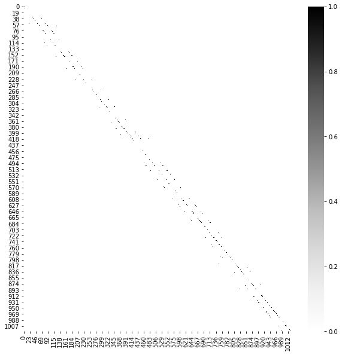

```python
def connect_alive_dead(covariance,alive_indexes,dead_indexes):
    connection_matrix_alive_dead = covariance.copy()
    connection_matrix_alive_dead[alive_indexes,:] = 0
    connection_matrix_alive_dead[:,dead_indexes] = 0
    max_per_line = np.max(connection_matrix_alive_dead,axis=1).reshape(-1,1)
    filtered_matrix_alive_dead = connection_matrix_alive_dead >= max_per_line
    connection_matrix_alive_dead = connection_matrix_alive_dead*filtered_matrix_alive_dead
    connection_matrix_alive_dead[alive_indexes,alive_indexes] = 1
    connection_matrix_alive_dead = (connection_matrix_alive_dead > 0)*1.0
    connection_matrix_alive_dead = connection_matrix_alive_dead.transpose()
    return np.expand_dims(np.expand_dims(connection_matrix_alive_dead,0),-1)
connection_matrix_alive_dead = connect_alive_dead(covariance,alive_indexes,dead_indexes)
plt.figure(figsize=(10,10))
seaborn.heatmap(connection_matrix_alive_dead[0,:,:,0],cmap="Greys")
```

# 3 - Fonction de Pooling

- Chaque noeud «vivant» a une vecteur de noeuds (tous les noeuds «morts» plus lui même)
- Nous allons garder pour chaque vecteur seulement la valeur la plus grande.
- Cette valeur va être la valeur du noeud «vivant»

## Seulement tensorflow, le code numpy ici c'est seulement pour verifier si ça marche

Ce code va être mis comme une couche lambda qu'execute cette fonction. Dans notre cas, convolution va être la reponse de la convolution, connection_matrix_alive_dead va etre un parametre précalculé

```python
def pooling(convolution_tf,connection_matrix_alive_dead,alive_indexes):
    connection_matrix_alive_dead_tf = tf.convert_to_tensor(connection_matrix_alive_dead,dtype=tf.float32)
    reorganized_convolution_tf = tf.expand_dims(convolution_tf,1)
    pooling_values_tf = reorganized_convolution_tf*connection_matrix_alive_dead_tf
    pooled_values_tf = tf.reduce_max(pooling_values_tf,axis=-2)
    result_tf = tf.gather(pooled_values_tf,alive_indexes,axis=1)
    return result_tf

def test_pooling(convolution_np,connection_matrix_alive_dead,alive_indexes):
    convolution_tf = tf.convert_to_tensor(convolution_np,dtype=tf.float32)
    alive_indexes = tf.convert_to_tensor(alive_indexes,dtype=tf.int32)
    tensorflow_result = sess.run((pooling(convolution_tf,connection_matrix_alive_dead,alive_indexes)))
    return tensorflow_result
```

### Numpy

```python
def numpy_pooling(convolution,connection_matrix_alive_dead,alive_indexes):
    reorganized_convolution = np.expand_dims(convolution,1)
    pooling_values = reorganized_convolution*connection_matrix_alive_dead
    pooled_values = pooling_values.max(axis=-2)
    result = pooled_values[:,alive_indexes,:]
    return result
test = numpy_pooling(convolution,connection_matrix_alive_dead,alive_indexes)
test[:,0,:]
```

```
array([[  100.,   101.,   102.],
       [ 3072.,  3071.,  3070.]])
```

```python
def check_numpy_tf(convolution,connection_matrix_alive_dead,alive_indexes):
    return np.all(test_pooling(convolution,connection_matrix_alive_dead,alive_indexes) ==
          numpy_pooling(convolution,connection_matrix_alive_dead,alive_indexes))
check_numpy_tf(convolution,connection_matrix_alive_dead,alive_indexes)
```

```
True
```

# 4 - Reconstruire le graphe

- Prendre la matrice de covariance
- Supprimer les lines et colonnes des «morts»
- 4-KNN sur chaque line
- Multiplier, element par element, la matrice d'adjacence et la matrice du 4-KNN

## Seulement numpy

Ce code nous donne comme sortie la nouvelle matrice d'adjacence et la nouvelle matrice de covariance. Ils seront utilisés pour créer des nouvelles couches de pooling et le nouveau S

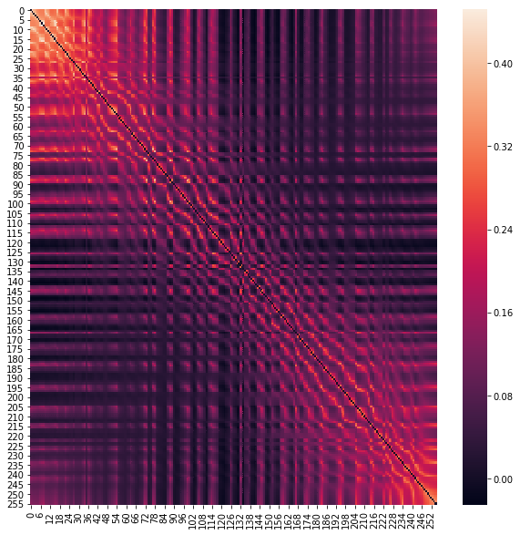

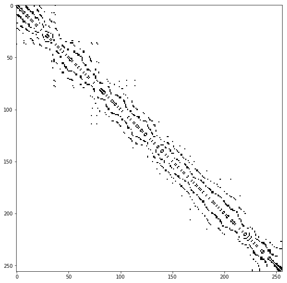

```python
def post_pooling_info(covariance,alive_indexes):
    new_graph_covariance = covariance.copy()
    new_graph_covariance = new_graph_covariance[alive_indexes,:]
    new_graph_covariance = new_graph_covariance[:,alive_indexes]
    new_adjacence_matrix, new_weighted_adjacence_matrix = create_adjacence_matrix_from_covariance(new_graph_covariance,4,)
    return new_graph_covariance, new_adjacence_matrix, new_weighted_adjacence_matrix
new_graph_covariance, new_adjacence_matrix, new_weighted_adjacence_matrix = post_pooling_info(covariance,alive_indexes)

plt.figure(figsize=(10,10))
seaborn.heatmap(new_graph_covariance)
plt.figure(figsize=(10,10))
plt.imshow(new_adjacence_matrix,cmap="Greys")
```

Executer une autre fois pour le deuxième pooling

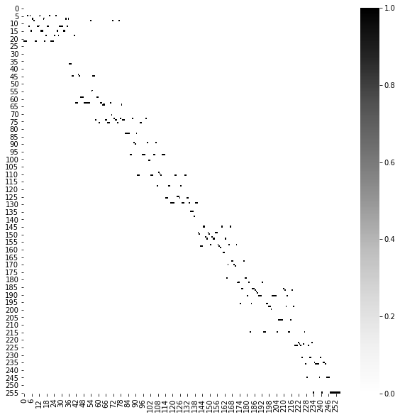

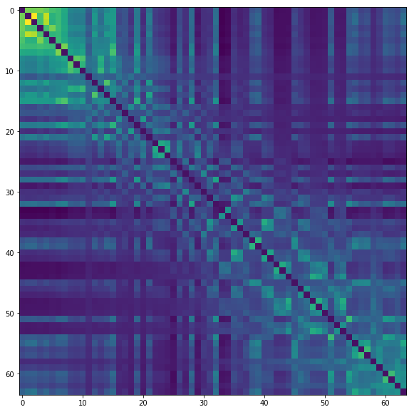

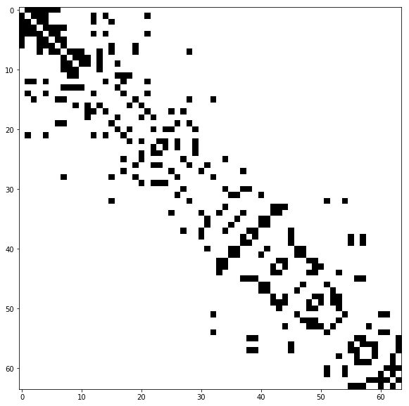

```python
new_alive_indexes,new_dead_indexes = choose_nodes(new_adjacence_matrix)
new_connection_matrix_alive_dead = connect_alive_dead(new_graph_covariance,new_alive_indexes,new_dead_indexes)
new_new_graph_covariance, new_new_adjacence_matrix, new_new_weighted_adjacence_matrix = post_pooling_info(
    new_graph_covariance,new_alive_indexes)

plt.figure(figsize=(10,10))
seaborn.heatmap(new_connection_matrix_alive_dead[0,:,:,0],cmap="Greys")
plt.figure(figsize=(10,10))
plt.imshow(new_new_graph_covariance)
plt.figure(figsize=(10,10))
plt.imshow(new_new_adjacence_matrix,cmap="Greys")
```

# Sauvegarder des résultats

- Pour les covariances il faut sauvegarder comme npy pour utilisation à posteriori
- Pour les matrices d'adjacence il faut sauvegarder pour chaque line les valeurs plus grandes que 0 en un «txt» et la matrice en npy
- Pour la matrice de connexion «morts»-«vivants» il faut sauvegarder comme npy pour mettre dans la couche keras
- Il faut aussi sauvegarder le vecteur de noeuds «vivants»

```python
np.save("../results/covariance1024",covariance)
np.save("../results/covariance256",new_graph_covariance)
np.save("../results/covariance64",new_new_graph_covariance)
np.save("../results/connection_matrix_alive_dead_1024_256",connection_matrix_alive_dead)
np.save("../results/connection_matrix_alive_dead_256_64",new_connection_matrix_alive_dead)
np.save("../results/adjacence1024",adjacence_matrix)
np.save("../results/adjacence256",new_adjacence_matrix)
np.save("../results/adjacence64",new_new_adjacence_matrix)
np.save("../results/alive256",alive_indexes)
np.save("../results/alive64",new_alive_indexes)
```

```python
def save_adjacence_matrix(adjacence_matrix, filename):
    f = open(filename, 'w')
    size_string = adjacence_matrix.shape[0].__str__()
    f.write(size_string + "\n")
    for i in range(adjacence_matrix.shape[0]):
        line = adjacence_matrix[i,:]
        values = np.where(line > 0)[0]
        values_str = list(values).__str__()[1:-1].strip().replace(",","")
        f.write(values_str+"\n")
    f.close()
save_adjacence_matrix(adjacence_matrix,"../results/Cifar1024Adjacence")
save_adjacence_matrix(new_adjacence_matrix,"../results/Cifar256Adjacence")
save_adjacence_matrix(new_new_adjacence_matrix,"../results/Cifar64Adjacence")
```